# Reproducible Research: Peer Assessment 1

ACrst

17 April 2019

## Loading and preprocessing the data

```r
if(!exists("activity.csv")){
  unzip("activity.zip")
}
if(!exists("activity.csv")){
act<-read.csv("activity.csv")
}

library(lubridate)
act$date<-as.Date(act$date)
```

# Histogram of the total number of steps taken each day

```r
library(dplyr)
library(reshape2)

actMeltDate<-melt(act,id.vars="date",measure.vars="steps",na.rm=TRUE)
actCastDate<-dcast(actMeltDate,date~variable,sum)
```

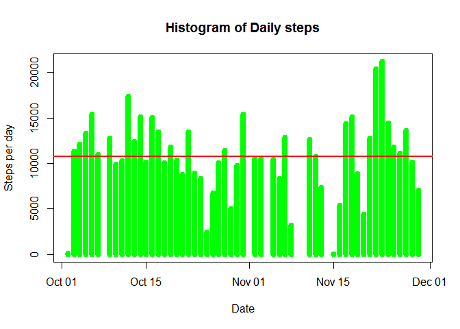

```r
plot(actCastDate$date,actCastDate$steps,type="h",main="Histogram of Daily steps",xlab="Date",ylab="Steps per day",col="green",lwd=8)
abline(h=mean(actCastDate$steps,na.rm=TRUE),col="red",lwd=2)
```

```r
meansteps<-mean(actCastDate$steps, na.rm = TRUE)
mediansteps<-median(actCastDate$steps,na.rm = TRUE)
```

## What is the average daily activity pattern?

```r
require(dplyr)
require(data.table)
actmeltInterval<-melt(act,id.vars="interval",measure.vars="steps",na.rm=TRUE)
actCastInterval<-dcast(actmeltInterval,interval~variable,mean)
```

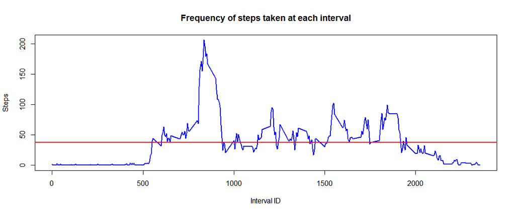

```r
plot(actCastInterval$interval,actCastInterval$steps,type="l",main="Frequency of steps taken at each interval",xlab="Interval ID", ylab="Steps",col="blue",lwd=2)
abline(h=mean(actCastInterval$steps,na.rm = TRUE),col="red",lwd=2)
```

#The 5-minute interval that, on average, contains the maximum number of steps

```r
paste("Interval with max value=",actCastInterval$interval[which(actCastInterval$steps==max(actCastInterval$steps))])
```

```
## [1] "Interval with max value= 835"
```

```r
paste("Maximum interval mean steps=",max(actCastInterval$steps))
```

```
## [1] "Maximum interval mean steps= 206.169811320755"
```

## Imputing missing values

```r
sum(is.na(act$steps))
```

```
## [1] 2304
```

Since there are a considerable number of missing values, we can replace the NAs with the mean for the particular interval number. For example, if the average number of steps taken during the interval x is y, we will replace each each NA with the corresponding y value for that row. Then we will recalculate the steps per day to see how much it differs from the original result(with NAs included).

```r
stepsperInterval<-actCastInterval
actNoNA<-act
actMerge=merge(actNoNA,stepsperInterval,by="interval",suffixes=c(".act",".spi"))
naIndex=which(is.na(actNoNA$steps))
actNoNA[naIndex,"steps"]=actMerge[naIndex,"steps.spi"]
```

Melt new data frame to prep for casting by date

```r
actMeltDateNoNA<-melt(actNoNA,id.vars="date",measure.vars="steps",na.rm=FALSE)
actCastDateNoNA<-dcast(actMeltDateNoNA,date~variable,sum)
```

# Histogram of the total number of steps taken each day after missing values are imputed

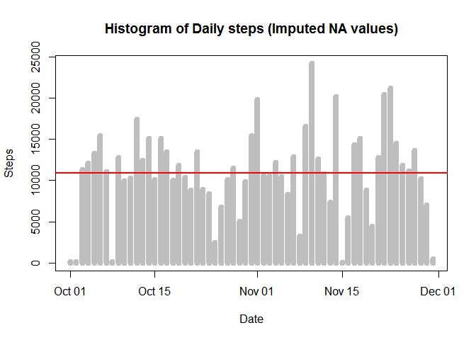

```r
plot(actCastDateNoNA$date,actCastDateNoNA$steps,type="h",main="Histogram of Daily steps (Imputed NA values)",xlab="Date",ylab="Steps",col="gray",lwd=8)
abline(h=mean(actCastDateNoNA$steps),col="red",lwd=2)
```

```r
paste("Mean daily steps=",mean(actCastDateNoNA$steps,na.rm = TRUE))
```

```
## [1] "Mean daily steps= 10889.7992576554"
```

```r
paste("Median daily steps=",median(actCastDateNoNA$steps,na.rm = TRUE))
```

```
## [1] "Median daily steps= 11015"
```

# Panel plot comparing the average number of steps taken per 5-minute interval across weekdays and weekends

```r
for(i in 1:nrow(actNoNA)){
  if(weekdays(actNoNA$date[i])=="Saturday" | weekdays(actNoNA$date[i])=="Sunday"){
    actNoNA$dayOfWeek[i]="weekend"
  } else{
     actNoNA$dayOfWeek[i]="weekday"
  }
}


actWeekday<-subset(actNoNA,dayOfWeek=="weekday")
actWeekend<-subset(actNoNA,dayOfWeek=="weekend")

actMeltWeekday<-melt(actWeekday,id.vars="interval",measure.vars="steps")
actMeltWeekend<-melt(actWeekend,id.vars="interval",measure.vars="steps")
actCastWeekday<-dcast(actMeltWeekday,interval~variable,mean)
actCastWeekend<-dcast(actMeltWeekend,interval~variable,mean)
```

## Are there differences in activity patterns between weekdays and weekends?

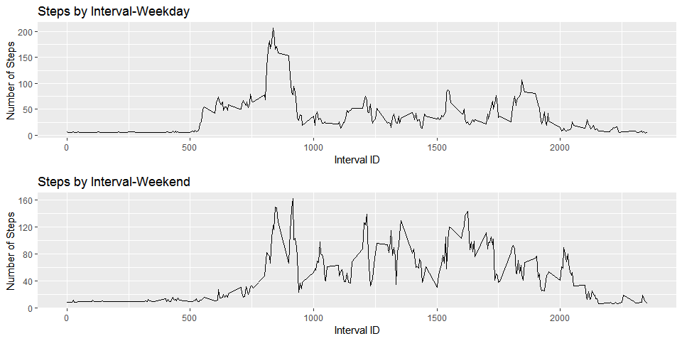

```r
library(ggplot2)
library(gridExtra)
plot1<-qplot(actCastWeekday$interval,actCastWeekday$steps,geom="line",data=actCastWeekday,type="bar",main="Steps by Interval-Weekday",xlab="Interval ID", ylab="Number of Steps")
plot2<-qplot(actCastWeekend$interval,actCastWeekend$steps,geom="line",data=actCastWeekend,type="bar",main="Steps by Interval-Weekend",xlab="Interval ID", ylab="Number of Steps")
grid.arrange(plot1,plot2,nrow=2)
```